# Eighth Week: Text Analysis in R

To be, or not to be

مهسا خوش نما 93101481

2018-05-08 02:22:00

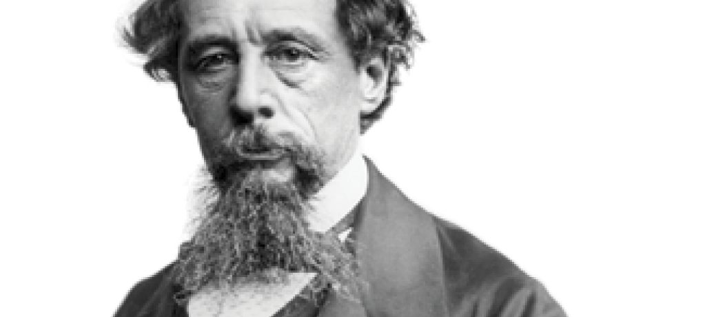

> با استفاده از بسته gutenberg داده های لازم را به دست آورید و به سوالات زیر پاسخ دهید.

```r
library(tm)
library(wordcloud)
library(stringr)
library(highcharter)
library(tidytext)
library(ggplot2)
library(highcharter)
library(dplyr)
library(gutenbergr)
library(wordcloud2)
library(car)
library(tidyr)
```

۱. چارلز دیکنز نویسنده معروف انگلیسی بالغ بر چهارده رمان (چهارده و نیم) نوشته است. متن تمامی کتاب های او را دانلود کنید و سپس بیست لغت برتر استفاده شده را به صورت یک نمودار ستونی نمایش دهید. (طبیعتا باید ابتدا متن را پاکسازی کرده و stopping words را حذف نمایید تا به کلماتی که بار معنایی مشخصی منتقل می کنند برسید.)

### پاسخ:

چند نکته قابل توجه است: برای حذف کلمه های زائدی که علائم نگارشی دارند، علائم نگارشی را از stopping words حذف کده و چک می کنیم که کلمات انتخابی از بین آن ها نباشند. همچنین برای شمارش تکرار کلمات، کلمات خاص و عام را پیدا کرده و کلمات عام را همگی به حروف کوچک تبدیل می کنیم.

```r
ThePickwickPapers = gutenberg_download(580)
OliverTwist = gutenberg_download(730)
NicholasNickleby = gutenberg_download(967)
TheOldCuriosityShop = gutenberg_download(700)
BarnabyRudge = gutenberg_download(917)
MartinChuzzlewit = gutenberg_download(968)
DombeyandSon = gutenberg_download(821)
DavidCopperfield =gutenberg_download(766)
BleakHouse =gutenberg_download(1023)
HardTimes =gutenberg_download(786)
LittleDorrit =gutenberg_download(963)
ATaleOfTwoCities = gutenberg_download(98)
GreatExpectations = gutenberg_download(1400)
OurMutualFriend = gutenberg_download(883)
TheMysteryofEdwinDrood =gutenberg_download(564)


novel_texts = c(ThePickwickPapers$text,OliverTwist$text,NicholasNickleby$text,
                TheOldCuriosityShop$text,BarnabyRudge$text,MartinChuzzlewit$text,
                DombeyandSon$text,DavidCopperfield$text,BleakHouse$text,
                HardTimes$text,LittleDorrit$text,ATaleOfTwoCities$text,
                GreatExpectations$text,OurMutualFriend$text,TheMysteryofEdwinDrood$text)

words = data.frame(word = novel_texts %>% str_split("\\s+") %>% unlist(),
                   stringsAsFactors = F)

words %>%
  filter(!(str_to_lower(word) %>% str_replace_all("[:punct:]","") %in%
             (stop_words$word %>% str_replace_all("[:punct:]","")))) %>%
  filter(!(str_to_lower(word) %in% (stop_words$word %>% str_replace_all("[:punct:]","")))) -> words
words$word =  str_replace_all(words$word,"[:punct:]","")
words %>%   filter(!(str_to_lower(word) %in% stop_words$word)) %>%
  filter(str_length(word)>1) %>%
  filter(!str_detect(word,"\\d")) %>%
  mutate(proper = !(str_to_lower(word) %in% word )) ->words

words$word[which(words$proper==0)] = str_to_lower(words$word[which(words$proper==0)])
words %>% group_by(word,proper) %>%
  summarise(count = as.numeric(n())) %>%  arrange(-count)-> words
words = data.frame(word = words$word,count = words$count,proper = words$proper)

hchart(words[1:20,],type = "column",hcaes(x = word, y =count,color = count),
       name = "count") %>%  hc_add_theme(hc_theme_google())
```

[interactive chart not shown]

۲. ابر لغات ۲۰۰ کلمه پرتکرار در رمان های چارلز دیکنز را رسم نمایید. این کار را با بسته wordcloud2 انجام دهید. برای دانلود می توانید به لینک زیر مراجعه کنید.

https://github.com/Lchiffon/wordcloud2

با استفاده از عکسی که در ابتدا متن آمده ابر لغاتی مانند شکل زیر رسم کنید. (راهنمایی: از ورودی figpath در دستور wordcloud2 استفاده نمایید.مثالی در زیر آورده شده است.)

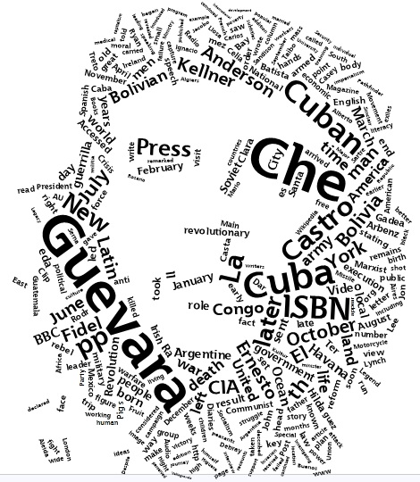

### پاسخ:

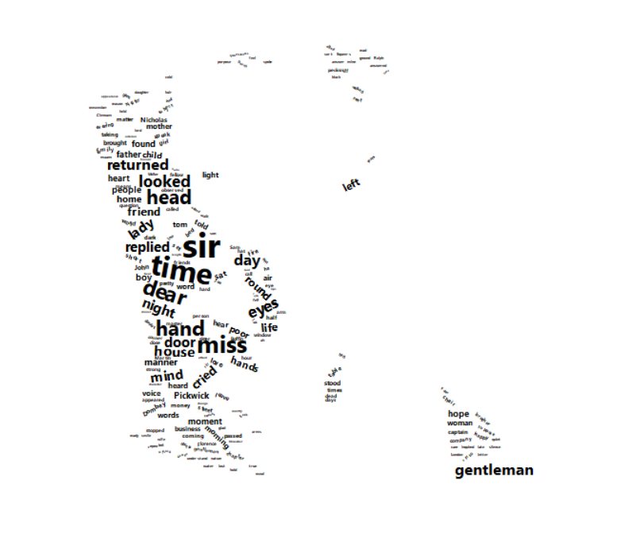

```r
wordcloud2(words %>% select(word,count) %>% .[1:200,],size = 0.2,color = 'black',
           figPath = "F:/University/8th Semester/Data Analysis/HWs/hw_08/images/dickens1_1.png")
```

۳. اسم پنج شخصیت اصلی در هر رمان دیکنز را استخراج کنید و با نموداری تعداد دفعات تکرار شده بر حسب رمان را رسم نمایید. (مانند مثال کلاس در رسم اسامی شخصیت ها در سری هر پاتر)

### پاسخ:

```r
###Q3
novels = list(ThePickwickPapers,OliverTwist,NicholasNickleby,
                TheOldCuriosityShop,BarnabyRudge,MartinChuzzlewit,
                DombeyandSon,DavidCopperfield,BleakHouse,
                HardTimes,LittleDorrit,ATaleOfTwoCities,
                GreatExpectations,OurMutualFriend,TheMysteryofEdwinDrood)

names = list()


for (i in 1:15){
  book = novels[[i]]
  words = data.frame(word = book$text %>% str_split("\\s+") %>% unlist(),
                     stringsAsFactors = F)
  words %>%
    filter(!(str_to_lower(word) %>% str_replace_all("[:punct:]","") %in%
               (stop_words$word %>% str_replace_all("[:punct:]","")))) %>%
    filter(!(str_to_lower(word) %in% (stop_words$word %>% str_replace_all("[:punct:]","")))) -> words
  words$word =  str_replace_all(words$word,"[:punct:]","")
  words %>%   filter(!(str_to_lower(word) %in% stop_words$word)) %>%
    filter(str_length(word)>1) %>%
    filter(!str_detect(word,"\\d")) %>%
    filter(!(str_to_lower(word) %in% word )) %>% group_by(word) %>%
    summarise(count = as.numeric(n())) %>%  arrange(-count)-> words
  words = data.frame(name = words$word[1:5],count = words$count[1:5],book_no =rep(i,5))
  names[[i]] = words[1:5,]
}

names = bind_rows(names)
names %>% mutate(book = recode(book_no,"1='ThePickwickPapers';2='OliverTwist';3='NicholasNickleby';
                4='TheOldCuriosityShop';5='BarnabyRudge';6='MartinChuzzlewit';
                7='DombeyandSon';8='DavidCopperfield';9='BleakHouse';
                10='HardTimes';11='LittleDorrit';12='ATaleOfTwoCities';
                13='GreatExpectations';14='OurMutualFriend';15='TheMysteryofEdwinDrood'")) -> names


hchart(names[1:25,],type = 'column',hcaes(x=name,y=count,group=book))%>%
  hc_add_theme(hc_theme_google())
```

[interactive chart not shown]

```r
hchart(names[26:50,],type = 'column',hcaes(x=name,y=count,group=book))%>%
  hc_add_theme(hc_theme_google())
```

[interactive chart not shown]

```r
hchart(names[51:75,],type = 'column',hcaes(x=name,y=count,group=book))%>%
  hc_add_theme(hc_theme_google())
```

[interactive chart not shown]

۴. در بسته tidytext داده ایی به نام sentiments وجود دارد که فضای احساسی لغات را مشخص می نماید. با استفاده از این داده نمودار ۲۰ لغت برتر negative و ۲۰ لغت برتر positive را در کنار هم رسم نمایید. با استفاده از این نمودار فضای حاکم بر داستان چگونه ارزیابی می کنید؟ (به طور مثال برای کتاب داستان دو شهر فضای احساسی داستان به ترتیب تکرر در نمودار زیر قابل مشاهده است.)

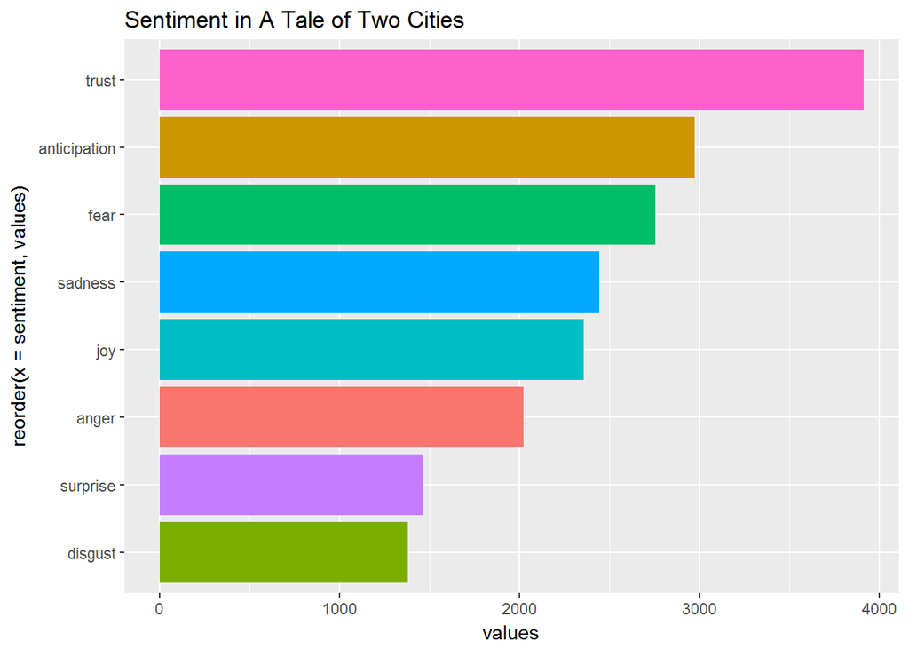

### پاسخ:

```r
sentiment_words = sentiments %>% filter(lexicon=="nrc") %>%
  filter(sentiment=="positive" | sentiment=="negative") %>% select(word,sentiment)
sentiment_words2 = sentiments %>% filter(lexicon=="nrc") %>%
  filter(sentiment %in% c("trust","anticipation","fear","sadness",
                          "joy","anger","surprise","disgust")) %>% select(word,sentiment)
positive = list()
negative = list()
senti_words = list()
for (i in 1:15){
  book = novels[[i]]
  words = data.frame(word = book$text %>% str_split("\\s+") %>% unlist(),
                     stringsAsFactors = F)

  words$word =  str_replace_all(words$word,"[:punct:]","")
  words %>%
    filter(str_length(word)>1) %>%
    filter(!str_detect(word,"\\d")) %>%
    mutate(proper = !(str_to_lower(word) %in% word )) ->words

  words$word[which(words$proper==0)] = str_to_lower(words$word[which(words$proper==0)])
  words %>% group_by(word,proper) %>%
    summarise(count = as.numeric(n())) %>%  arrange(-count)-> words
  words = data.frame(word = words$word,count = words$count) %>% mutate(book_no =i)
  words1 = merge(words,sentiment_words)
  positive[[i]] = words1 %>% filter(sentiment=="positive") %>% arrange(-count) %>% slice(1:20)
  negative[[i]] = words1 %>% filter(sentiment=="negative") %>% arrange(-count) %>% slice(1:20)
  words2 = merge(words,sentiment_words2)
  senti_words[[i]] = words2 %>% group_by(sentiment,book_no) %>% summarise(count= sum(count)) %>%
    arrange(-count)
}


positive = bind_rows(positive)
positive %>% mutate(book = recode(book_no,"1='\"The Pickwick Papers\"';2='\"Oliver Twist\"';
                               3='\"NicholasNickleby\"';
                               4='\"TheOldCuriosityShop\"';5='\"BarnabyRudge\"';6='\"MartinChuzzlewit\"';
                               7='\"DombeyandSon\"';8='\"DavidCopperfield\"';9='\"BleakHouse\"';
                               10='\"HardTimes\"';11='\"LittleDorrit\"';12='\"ATaleOfTwoCities\"';
                               13='\"GreatExpectations\"';14='\"OurMutualFriend\"';
                                    15='\"TheMysteryofEdwinDrood\"'")) -> positive

negative = bind_rows(negative)
negative %>% mutate(book = recode(book_no,"1='\"The Pickwick Papers\"';2='\"Oliver Twist\"';
                               3='\"NicholasNickleby\"';
                                4='\"TheOldCuriosityShop\"';5='\"BarnabyRudge\"';6='\"MartinChuzzlewit\"';
                                  7='\"DombeyandSon\"';8='\"DavidCopperfield\"';9='\"BleakHouse\"';
                                  10='\"HardTimes\"';11='\"LittleDorrit\"';12='\"ATaleOfTwoCities\"';
                                  13='\"GreatExpectations\"';14='\"OurMutualFriend\"';
                                  15='\"TheMysteryofEdwinDrood\"'")) -> negative

senti_words = bind_rows(senti_words)
senti_words %>% mutate(book = recode(book_no,"1='\"The Pickwick Papers\"';2='\"Oliver Twist\"';
                               3='\"NicholasNickleby\"';
                                4='\"TheOldCuriosityShop\"';5='\"BarnabyRudge\"';6='\"MartinChuzzlewit\"';
                                  7='\"DombeyandSon\"';8='\"DavidCopperfield\"';9='\"BleakHouse\"';
                                  10='\"HardTimes\"';11='\"LittleDorrit\"';12='\"ATaleOfTwoCities\"';
                                  13='\"GreatExpectations\"';14='\"OurMutualFriend\"';
                                  15='\"TheMysteryofEdwinDrood\"'")) -> senti_words

senti_words = data.frame(sentiment = senti_words$sentiment,count = senti_words$count,
                         book = senti_words$book)
plot_list = list()
for(i in 1:15){

  hc = hchart(positive[((i-1)*20+1):(i*20),],type = 'column',color='red', hcaes(x = word,y=count),name='count') %>%
      hc_title(text = paste(positive$book[i*20],"Positive Words"," "))
  plot_list[[3*i-2]] = hc
  hc = hchart(negative[((i-1)*20+1):(i*20),],type = 'column',color='blue', hcaes(x = word,y=count)) %>%
    hc_title(text = paste(negative$book[i*20],"Negative Words"," "))
  plot_list[[3*i-1]] = hc
  hc = hchart(senti_words[((i-1)*8+1):(i*8),],type = 'bar',
              hcaes(x = sentiment,y=count,color=as.factor(sentiment))) %>%
    hc_title(text = paste(negative$book[i*20],"Sentiments"," ")) %>%
    hc_add_theme(hc_theme_ffx())
  plot_list[[3*i]] = hc
}


htmltools::tagList(plot_list[1:3])
```

[interactive chart not shown]

فضای کتاب، با توجه به تعداد به نسبت بسیار بیشتر کلمات مثبت، مثبت است.

```r
htmltools::tagList(plot_list[4:6])
```

[interactive chart not shown]

تعداد لغات مثبت، به نسبت بیشتر هستندو فضا نسبتا مثبت است. در نمودار سوم گرچه مشاهده می شود که احساستی همچون ترس و ناراحتی هم به نسبت در کتاب زیاد ظاهر شده اند.

```r
htmltools::tagList(plot_list[7:9])
```

[interactive chart not shown]

فضای کتاب، با توجه به تعداد به نسبت بسیار بیشتر کلمات مثبت، مثبت است.

```r
htmltools::tagList(plot_list[10:12])
```

[interactive chart not shown]

فضای کتاب، با توجه به تعداد به نسبت بسیار بیشتر کلمات مثبت، مثبت است.

```r
htmltools::tagList(plot_list[13:15])
```

[interactive chart not shown]

فضای کتاب، با توجه به تعداد به نسبت بسیار بیشتر کلمات مثبت، مثبت است.

به همین ترتیب با استفاده از نمودارهای زیر می توان به طور نسبی از فضای داستان ها آگاه شد.

```r
htmltools::tagList(plot_list[16:45])
```

[interactive chart not shown]

***

۵. متن داستان بینوایان را به ۲۰۰ قسمت مساوی تقسیم کنید. برای هر قسمت تعداد لغات positive و negative را حساب کنید و سپس این دو سری زمانی را در کنار هم برای مشاهده فضای احساسی داستان رسم نمایید.

### پاسخ:

```r
gutenberg_metadata %>% filter(str_detect(author,"Hugo")) -> Hugo

LesMiserables = gutenberg_download(135)
text = LesMiserables$text[-(1:624)]

words = data.frame(word = text %>% str_split("\\s+") %>% unlist(),
                   stringsAsFactors = F)
words$section = ceiling(200*(1:nrow(words))/nrow(words))
words$word =  str_replace_all(words$word,"[:punct:]","")
words %>%
  filter(str_length(word)>1) %>%
  filter(!str_detect(word,"\\d")) %>%
  mutate(proper = !(str_to_lower(word) %in% word )) ->words

words$word[which(words$proper==0)] = str_to_lower(words$word[which(words$proper==0)])
words %>% group_by(word,section) %>%
  summarise(count = as.numeric(n())) %>%  arrange(section,-count)-> words
words = data.frame(word = words$word,section = words$section,count = words$count)
words = merge(words,sentiment_words)
words = words %>% group_by(section,sentiment) %>%
  summarise(count = sum(count))
w = words %>% group_by(section) %>% summarise(c = sum(count))
words %>% mutate(normalised_count = 0) -> words
words$normalised_count[which(words$sentiment=='positive')] =
  words$count[which(words$sentiment=='positive')]/w$c
words$normalised_count[which(words$sentiment=='negative')] =
  words$count[which(words$sentiment=='negative')]/w$c
words %>%
  hchart(type = "line", hcaes(x = section, y = normalised_count, group = sentiment)) %>%
  hc_legend(align = "right", verticalAlign = "top",
            layout = "vertical", x = 0, y = 100) %>% hc_add_theme(hc_theme_google())
```

[interactive chart not shown]

```r
sections = data.frame(section = (1:200),net_normalised_count =
                        words$normalised_count[which(words$sentiment=='positive')] -
                        words$normalised_count[which(words$sentiment=='negative')]) %>%
  mutate(sense = ifelse(net_normalised_count>0 ,"positive","negative"))

sections %>%
  hchart(type = "line", hcaes(x = section, y = net_normalised_count)) %>%
    hc_add_theme(hc_theme_google())
```

[interactive chart not shown]

مشاهده می شود که فضای کتاب، به شدت بین مثبت و منفی نوسان می کند. در انتها برای بازه ای فضا منفی شده ولی نهایتا با فضای مثبت به پایان می رسد.

۶. ابتدا ترکیبات دوتایی کلماتی که پشت سر هم می آیند را استخراج کنید و سپس نمودار ۳۰ جفت لغت پرتکرار را رسم نمایید.

### پاسخ:

```r
LesMiserables$text = str_replace_all(LesMiserables$text,"[:punct:]"," ")
LesMiserables %>% mutate(bigram = "")->bigrams
unnest_tokens(bigrams,bigram,text , token = "ngrams", n = 2)->bigrams

bigrams = bigrams$bigram %>%
  table() %>% as.data.frame(stringsAsFactors =F) -> bigrams

colnames(bigrams) = c("bigram","count")
bigrams %>% filter(!str_detect(bigram,"\\d")) -> bigrams
bigrams %>%
  separate(bigram, c("word1", "word2"), sep = " ") -> bigrams_separated

bigrams$word1 =  bigrams_separated$word1
bigrams$word2 =  bigrams_separated$word2

bigrams %>% filter(!(str_to_lower(word1) %in% stopwords('en')) &
                   !(str_to_lower(word1) %in% stopwords('fr')) &
                   !(str_to_lower(word2) %in% stopwords('en')) &
                   !(str_to_lower(word2) %in% stopwords('fr'))) -> bigrams


bigrams %>% arrange(-count) %>% slice(1:30) -> bigrams
hchart(bigrams,type = 'column',hcaes(x = bigram,y=count,color = -count), name='count') %>%
  hc_add_theme(hc_theme_google()) %>% hc_title(text="Bigrams in \"Les Miserables\"")
```

[interactive chart not shown]

۷. جفت کلماتی که با she و یا he آغاز می شوند را استخراج کنید. بیست فعل پرتکراری که زنان و مردان در داستان های دیکنز انجام می دهند را استخراج کنید و نمودار آن را رسم نمایید.

### پاسخ:

```r
LesMiserables %>% mutate(bigram = "")->bigrams
unnest_tokens(bigrams,bigram,text , token = "ngrams", n = 2)->bigrams


bigrams$bigram = bigrams$bigram %>% str_to_lower()
bigrams %>%
  separate(bigram, c("word1", "word2"), sep = " ") -> bigrams_separated

bigrams$word1 =  bigrams_separated$word1
bigrams$word2 =  bigrams_separated$word2

bigrams %>% filter(word1=='he'|word1=='she') %>% .$word2 -> verbs
verbs = verbs %>%
  table() %>% as.data.frame(stringsAsFactors =F)
colnames(verbs) = c("verb","count")
verbs %>% arrange(-count) -> verbs
hchart(verbs[1:20,],type = 'column',hcaes(x = verb,y=count,color = -count), name='count') %>%
  hc_add_theme(hc_theme_google()) %>% hc_title(text="Verbs in \"Les Miserables\"")
```

[interactive chart not shown]

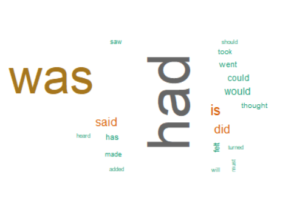

```r
wordcloud(verbs$verb[1:20],verbs$count[1:20],size=2,
          c(5,.3), random.order = FALSE, colors=brewer.pal(8, "Dark2"))
```

۸. برای کتاب های دیکنز ابتدا هر فصل را جدا کنید. سپی برای هر فصل 1-gram, 2-gram را استخراج کنید. آیا توزیع N-gram در کارهای دیکنز یکسان است؟ با رسم نمودار هم این موضوع را بررسی کنید.